# Select number of topics for LDA model

Murzintcev Nikita

2020-04-08

Package can be installed from CRAN

```r
install.packages("ldatuning")
```

or downloaded from the GitHub repository (developer version).

```r
install.packages("devtools")
devtools::install_github("nikita-moor/ldatuning")
```

Package `ldatuning` realizes 4 metrics to select perfect number of topics for LDA model.

```r
library("ldatuning")
```

Load “AssociatedPress” dataset from the `topicmodels` package.

```r
library("topicmodels")
data("AssociatedPress", package="topicmodels")
dtm <- AssociatedPress[1:10, ]
```

The most easy way is to calculate all metrics at once. All existing methods require to train multiple LDA models to select one with the best performance. It is computation intensive procedure and `ldatuning` uses parallelism, so do not forget to point correct number of CPU cores in `mc.core` parameter to archive the best performance.

All standard LDA methods and parameters from `topimodels` package can be set with `method` and `control`.

```r
result <- FindTopicsNumber(
  dtm,
  topics = seq(from = 2, to = 15, by = 1),
  metrics = c("Griffiths2004", "CaoJuan2009", "Arun2010", "Deveaud2014"),
  method = "Gibbs",
  control = list(seed = 77),
  mc.cores = 2L,
  verbose = TRUE
)
```

```
## fit models... done.
## calculate metrics:
##   Griffiths2004... done.
##   CaoJuan2009... done.
##   Arun2010... done.
##   Deveaud2014... done.
```

Result is a number of topics and corresponding values of metrics

| topics | Griffiths2004 | CaoJuan2009 | Arun2010 | Deveaud2014 |
| --- | --- | --- | --- | --- |
| 15 | -15297.82 | 0.5047240 | 15.92711 | 0.1362596 |
| 14 | -15338.24 | 0.4927860 | 15.36552 | 0.1406462 |
| 13 | -15319.82 | 0.4944709 | 15.80569 | 0.1504368 |
| 12 | -15326.94 | 0.4756351 | 15.81278 | 0.1594651 |
| 11 | -15293.55 | 0.4347111 | 15.23313 | 0.1770861 |
| 10 | -15291.00 | 0.3829542 | 14.93706 | 0.1969989 |
| 9 | -15303.87 | 0.3379840 | 14.71664 | 0.2181424 |
| 8 | -15256.30 | 0.3061726 | 14.78140 | 0.2435689 |
| 7 | -15259.80 | 0.2746812 | 14.82908 | 0.2746203 |
| 6 | -15251.04 | 0.2612029 | 15.28425 | 0.3101625 |
| 5 | -15226.91 | 0.1875260 | 15.34470 | 0.3718687 |
| 4 | -15242.86 | 0.1779016 | 16.29708 | 0.4323482 |
| 3 | -15266.66 | 0.1600736 | 16.97832 | 0.5318997 |
| 2 | -15349.79 | 0.1169522 | 18.47430 | 0.6989189 |

Simple approach in analyze of metrics is to find extremum, more complete description is in corresponding papers:

- minimization:
  - Arun2010 [1]
  - CaoJuan2009 [2]
- maximization:
  - Deveaud2014 [3]
  - Griffiths2004 [4,5]

Support function `FindTopicsNumber_plot` can be used for easy analyze of the results

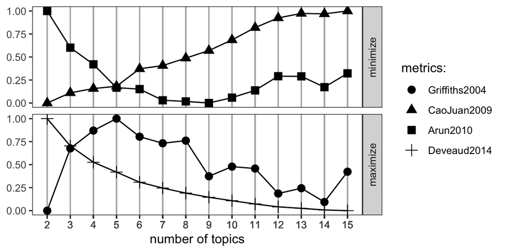

```r
FindTopicsNumber_plot(result)
```

Results calculated on the whole dataset (about 10 hours on quad-core computer) look like

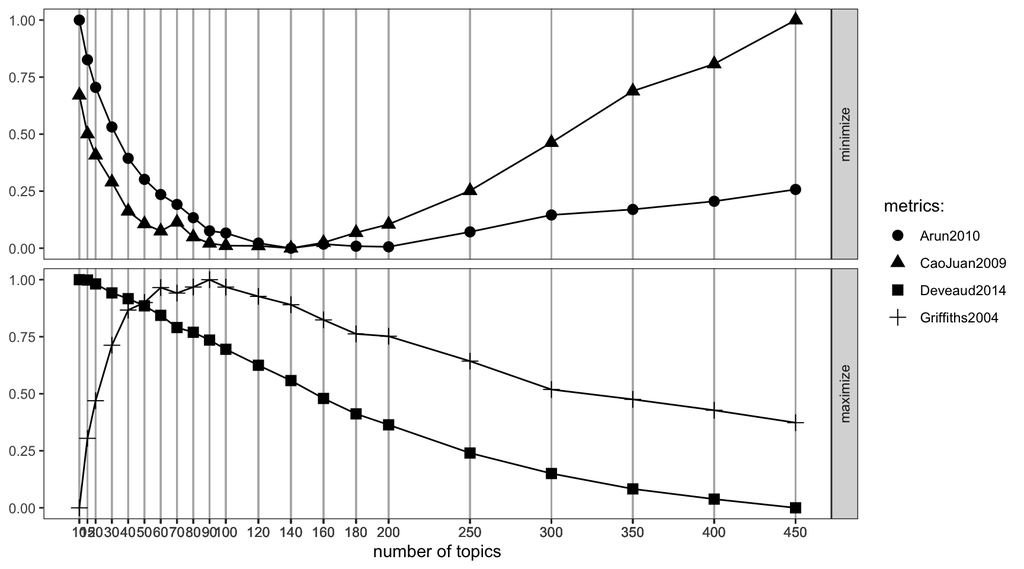

From this plot can be made conclusion that optimal number of topics is in range 90-140. Metric Deveaud2014 is not informative in this situation.

# References

1. Rajkumar Arun, V. Suresh, C. E. Veni Madhavan, and M. N. Narasimha Murthy. 2010. On finding the natural number of topics with latent dirichlet allocation: Some observations. In *Advances in knowledge discovery and data mining*, Mohammed J. Zaki, Jeffrey Xu Yu, Balaraman Ravindran and Vikram Pudi (eds.). Springer Berlin Heidelberg, 391–402. http://doi.org/10.1007/978-3-642-13657-3_43

2. Cao Juan, Xia Tian, Li Jintao, Zhang Yongdong, and Tang Sheng. 2009. A density-based method for adaptive lda model selection. *Neurocomputing — 16th European Symposium on Artificial Neural Networks 2008* 72, 7–9: 1775–1781. http://doi.org/10.1016/j.neucom.2008.06.011

3. Romain Deveaud, Éric SanJuan, and Patrice Bellot. 2014. Accurate and effective latent concept modeling for ad hoc information retrieval. *Document numérique* 17, 1: 61–84. http://doi.org/10.3166/dn.17.1.61-84

4. Thomas L. Griffiths and Mark Steyvers. 2004. Finding scientific topics. *Proceedings of the National Academy of Sciences* 101, suppl 1: 5228–5235. http://doi.org/10.1073/pnas.0307752101

5. Martin Ponweiser. 2012. Latent dirichlet allocation in r. Retrieved from http://epub.wu.ac.at/id/eprint/3558